# data_mining_project

This highlights a clear preference for private, well-equipped accommodations, with traditional options like Hostels and Hotels receiving more varied responses, underscoring the importance of property type in shaping guest experiences in Airbnb stays.

[output not shown]

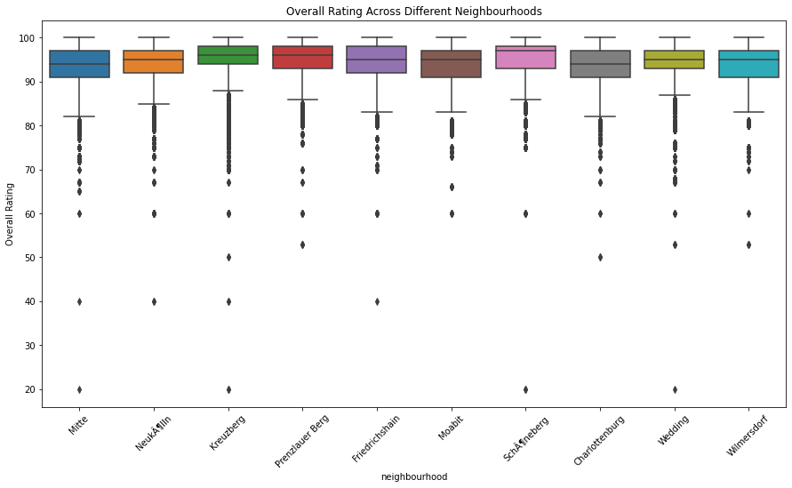

```python
#since 'neighbourhood' column has many unique values, we'll focus on the most common neighbourhoods for clarity in visualization
#filtering the top 10 most common neighbourhoods
top_neighbourhoods = airbnb_data_encoded['neighbourhood'].value_counts().head(10).index

#creating a new dataframe with only the top neighbourhoods
filtered_data_neighbourhood = airbnb_data_encoded[airbnb_data_encoded['neighbourhood'].isin(top_neighbourhoods)]

#creating a box plot for 'Overall Rating' across the top neighbourhoods
plt.figure(figsize=(15, 8))
sns.boxplot(x='neighbourhood', y='Overall Rating', data=filtered_data_neighbourhood)
plt.xticks(rotation=45)
plt.title('Overall Rating Across Different Neighbourhoods')
plt.show
```

```python
#calculating the average 'Overall Rating' for each neighbourhood
average_ratings_by_neighbourhood = airbnb_data_encoded.groupby('neighbourhood')['Overall Rating'].mean().sort_values(ascending=False)

#displaying the top and bottom 5 neighbourhoods in terms of average 'Overall Rating'
top_neighbourhoods = average_ratings_by_neighbourhood.head(5)
bottom_neighbourhoods = average_ratings_by_neighbourhood.tail(5)

top_neighbourhoods, bottom_neighbourhoods
```

```
(neighbourhood
 Marienfelde      98.338462
 Blankenburg      98.006803
 Wannsee          97.728395
 Schmargendorf    97.645102
 Waidmannslust    97.593137
 Name: Overall Rating, dtype: float64,
 neighbourhood
 MÃ¤rkisches Viertel      91.875000
 Hellersdorf              91.849112
 Buch                     91.400000
 KonradshÃ¶he             90.727273
 Neu-HohenschÃ¶nhausen    86.769231
 Name: Overall Rating, dtype: float64)
```

This analysis provides a clear picture of how guest satisfaction varies across different areas of Berlin. The top-rated neighbourhoods might be offering unique experiences, better amenities, or other desirable features that lead to higher guest satisfaction. Conversely, the lower-rated neighbourhoods might have certain drawbacks or lack features that are important to Airbnb guests.

```python
#calculating the average 'Overall Rating' for each postal code
average_ratings_by_postal_code = airbnb_data_encoded.groupby('Postal Code')['Overall Rating'].mean().sort_values(ascending=False)

#displaying the top and bottom 5 postal codes in terms of average 'Overall Rating'
top_postal_codes = average_ratings_by_postal_code.head(5)
bottom_postal_codes = average_ratings_by_postal_code.tail(5)

top_postal_codes, bottom_postal_codes
```

```
(Postal Code
 12357      100.0
 10347.0    100.0
 13583      100.0
 13467      100.0
 13439      100.0
 Name: Overall Rating, dtype: float64,
 Postal Code
 13627      80.000000
 12627      80.000000
 12249      80.000000
 13435.0    76.588235
 13469      75.000000
 Name: Overall Rating, dtype: float64)
```

This analysis provides a snapshot of the geographical distribution of customer satisfaction across different postal codes in Berlin. It's important to consider other factors like the number of listings and reviews in each postal code to fully understand these trends.

```python
#cross-analysis of other variables like price, property type, and room type across different postal codes
#calculating the average price for each postal code
average_price_by_postal_code = airbnb_data_encoded.groupby('Postal Code')['Price'].mean().sort_values(ascending=False)

#most common property and room types for each postal code
#for simplicity, we select the most common type in each postal code
most_common_property_type_by_postal_code = airbnb_data_encoded.groupby('Postal Code')['Property Type'].agg(lambda x: x.value_counts().index[0])
most_common_room_type_by_postal_code = airbnb_data_encoded.groupby('Postal Code')['Room Type'].agg(lambda x: x.value_counts().index[0])
```

```python
#combining these results into a single dataframe
postal_code_analysis = pd.DataFrame({
    'Average Rating': average_ratings_by_postal_code,
    'Average Price': average_price_by_postal_code,
    'Most Common Property Type': most_common_property_type_by_postal_code,
    'Most Common Room Type': most_common_room_type_by_postal_code
})

#displaying the combined data for the top 5 and bottom 5 postal codes in terms of average rating
top_postal_codes_analysis = postal_code_analysis.loc[top_postal_codes.index]
bottom_postal_codes_analysis = postal_code_analysis.loc[bottom_postal_codes.index]

top_postal_codes_analysis, bottom_postal_codes_analysis
```

```
(             Average Rating  Average Price Most Common Property Type  \
 Postal Code
 12357                 100.0          100.0               Condominium
 10347.0               100.0           55.0                 Apartment
 13583                 100.0           35.0                 Apartment
 13467                 100.0           53.0                 Apartment
 13439                 100.0           28.0                 Apartment

             Most Common Room Type
 Postal Code
 12357                Private room
 10347.0           Entire home/apt
 13583             Entire home/apt
 13467             Entire home/apt
 13439             Entire home/apt  ,
              Average Rating  Average Price Most Common Property Type  \
 Postal Code
 13627             80.000000      60.000000                 Apartment
 12627             80.000000      25.000000                 Apartment
 12249             80.000000      21.000000                 Apartment
 13435.0           76.588235     123.823529                 Apartment
 13469             75.000000      90.000000        Serviced apartment

             Most Common Room Type
 Postal Code
 13627             Entire home/apt
 12627                Private room
 12249                Private room
 13435.0           Entire home/apt
 13469             Entire home/apt  )
```

```python
#analyzing the impact of Superhost status on overall ratings
superhost_ratings = airbnb_data_encoded.groupby('Is Superhost')['Overall Rating'].mean()

superhost_ratings
```

```
Is Superhost
f    92.643768
t    96.825070
Name: Overall Rating, dtype: float64
```

```python
#analyzing the impact of Host Response Time on overall ratings
#since Host Response Time is a categorical variable, we will calculate the average rating for each category
response_time_ratings = airbnb_data_encoded.groupby('Host Response Time')['Overall Rating'].mean().sort_values(ascending=False)

#analyzing the impact of Host Response Rate on overall ratings
#converting Host Response Rate to a numeric value (it might be in percentage format)
airbnb_data_encoded['Host Response Rate'] = airbnb_data_encoded['Host Response Rate'].str.rstrip('%').astype('float') / 100
response_rate_ratings = airbnb_data_encoded.groupby(pd.cut(airbnb_data_encoded['Host Response Rate'], bins=5))['Overall Rating'].mean()

response_time_ratings, response_rate_ratings
```

```
(Host Response Time
 within a day          94.990531
 within a few hours    94.941094
 within an hour        94.419338
 a few days or more    93.706204
 Name: Overall Rating, dtype: float64,
 Host Response Rate
 (-0.001, 0.2]    94.549615
 (0.2, 0.4]       92.886117
 (0.4, 0.6]       94.300639
 (0.6, 0.8]       93.687998
 (0.8, 1.0]       94.628440
 Name: Overall Rating, dtype: float64)
```

#### SENTIMENT ANALYSIS

```python
nltk.download('averaged_perceptron_tagger')
```

```
True
```

```python
def analyze_sentiment(comment):
    #check if the comment is a string
    if isinstance(comment, str):
        analysis = TextBlob(comment)
        return analysis.sentiment.polarity
    else:
        #return None or a neutral sentiment score like 0 for non-string inputs
        return 0


#applying the function to your comments column
airbnb_data_encoded['Sentiment Score'] = airbnb_data_encoded['Processed_Comments'].apply(analyze_sentiment)
```

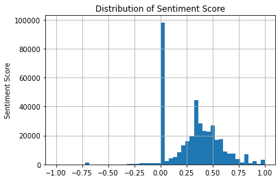

```python
#calculating the average and median sentiment scores, and plotting a histogram for visualization
average_sentiment = airbnb_data_encoded['Sentiment Score'].mean()
median_sentiment = airbnb_data_encoded['Sentiment Score'].median()

#plotting a histogram
airbnb_data_encoded['Sentiment Score'].hist(bins=50)
plt.title("Distribution of Sentiment Score")
plt.ylabel("Sentiment Score")
```

```python
average_sentiment, median_sentiment
```

```
(0.31369773051153277, 0.3333333333333333)
```

Both the average and median being positive suggest that the majority of reviews are positive, or at least more reviews are positive than negative. The close values of the mean and median indicate a relatively consistent sentiment across the dataset without extreme outliers skewing the results significantly.

```python
#categorizing sentiments into Positive, Neutral, and Negative.
def categorize_sentiment(score):
    if score > 0.1:
        return 'Positive'
    elif score < -0.1:
        return 'Negative'
    else:
        return 'Neutral'

airbnb_data_encoded['Sentiment Category'] = airbnb_data_encoded['Sentiment Score'].apply(categorize_sentiment)
```

```python
#for the analysis, we will compare sentiment scores across Room Type, Host Status, and Property Type
#grouping by Room Type and calculating the average sentiment score
average_sentiment_by_room = airbnb_data_encoded.groupby('Room Type')['Sentiment Score'].mean()

#grouping by Host Status and calculating the average sentiment score
average_sentiment_by_host_status = airbnb_data_encoded.groupby('Is Superhost')['Sentiment Score'].mean()

#grouping by Property Type and calculating the average sentiment score
average_sentiment_by_property_type = airbnb_data_encoded.groupby('Property Type')['Sentiment Score'].mean()
```

```python
#displaying the results
average_sentiment_by_room
```

```
Room Type
Entire home/apt    0.317380
Private room       0.309278
Shared room        0.307962
Name: Sentiment Score, dtype: float64
```

```python
average_sentiment_by_host_status
```

```
Is Superhost
f    0.302682
t    0.326625
Name: Sentiment Score, dtype: float64
```

```python
average_sentiment_by_property_type
```

```
Property Type
Aparthotel               0.210977
Apartment                0.315595
Barn                     0.162456
Bed and breakfast        0.299335
Boat                     0.167221
Boutique hotel           0.363068
Bungalow                 0.206630
Cabin                    0.239675
Camper/RV                0.258163
Castle                   0.227483
Cave                     0.333091
Condominium              0.322133
Cottage                  0.249379
Earth house              0.000000
Guest suite              0.288157
Guesthouse               0.238036
Hostel                   0.297489
Hotel                    0.290910
House                    0.238549
Houseboat                0.212165
Hut                      0.253745
Loft                     0.344733
Other                    0.244664
Pension (South Korea)    0.100000
Resort                   0.212477
Serviced apartment       0.315747
Tiny house               0.244136
Townhouse                0.254583
Train                    0.257292
Treehouse                0.000000
Villa                    0.212188
Name: Sentiment Score, dtype: float64
```

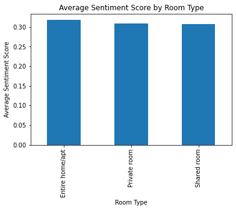

```python
#plotting the average sentiment by room type
average_sentiment_by_room = airbnb_data_encoded.groupby('Room Type')['Sentiment Score'].mean()
average_sentiment_by_room.plot(kind='bar')
plt.title('Average Sentiment Score by Room Type')
plt.ylabel('Average Sentiment Score')
plt.xlabel('Room Type')
plt.show()
```

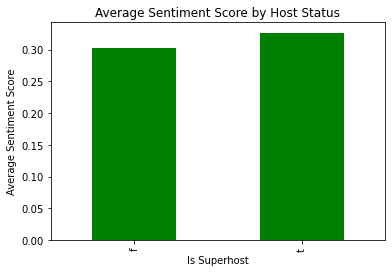

```python
#average Sentiment by Host Status (Superhost)
average_sentiment_by_host_status = airbnb_data_encoded.groupby('Is Superhost')['Sentiment Score'].mean()
average_sentiment_by_host_status.plot(kind='bar', color='green')
plt.title('Average Sentiment Score by Host Status')
plt.ylabel('Average Sentiment Score')
plt.xlabel('Is Superhost')
plt.show()
```

```python
#correlation between sentiment scores and numerical ratings
correlation = airbnb_data_encoded['Sentiment Score'].corr(airbnb_data_encoded['Overall Rating'])
correlation
```

```
0.0692713830873256
```

```python
#defining thresholds for extremely high and low sentiment scores
high_threshold = airbnb_data_encoded['Sentiment Score'].quantile(0.95)
low_threshold = airbnb_data_encoded['Sentiment Score'].quantile(0.05)

#filtering the dataset to find comments with extremely high sentiment scores
extremely_high_sentiment = airbnb_data_encoded[airbnb_data_encoded['Sentiment Score'] >= high_threshold]

#filtering the dataset to find comments with extremely low sentiment scores
extremely_low_sentiment = airbnb_data_encoded[airbnb_data_encoded['Sentiment Score'] <= low_threshold]

#displaying the comments with extremely high sentiment scores
print("Comments with Extremely High Sentiment Scores:")
print(extremely_high_sentiment[['Processed_Comments', 'Sentiment Score']])
```

```
Comments with Extremely High Sentiment Scores:
                                       Processed_Comments  Sentiment Score
21      aki really nice person perfect comunication cl...         0.741667
93                                          awesome house         1.000000
102     nous avon accueilli trs chaleureusement par ma...         0.750000
137                         nice apartment wonderful host         0.800000
180     everyhing superb great marius kind thx everythinh         0.800000
...                                                   ...              ...
456896                          perfect always thx martin         1.000000
456922  great location great host martin provides best...         0.866667
456924  martin home great location perfect close train...         0.883333
456942                                            perfect         1.000000
456950                          awesome hospitality loved         0.850000

[19882 rows x 2 columns]
```